# Crude Oil Production and Evacuation Analytics: Drivers of Zone-Level Throughput Performance

Author

Abiba Badmus — 2026/31/E/1647

Published

May 19, 2026

## 1. Executive Summary

This analysis evaluates where daily production losses are occurring and which operational levers can recover output against plan. The business context is high-stakes: sustaining throughput toward national production obligations and an internal 2026 evacuation target of 18 million barrels. I analyzed two internal operational datasets from January 1 to May 5, 2026: 625 station-level production records and 250 zone-level evacuation records.

## 2. Professional Disclosure

**Job title:** Head, Alternative Crude Oil Evacuation **Organisation sector:** Upstream oil and gas operations - national crude production, zone-level throughput management, and evacuation logistics

### Technique 1 — Exploratory Data Analysis

As Head of Alternative Crude Oil Evacuation, every working day begins with a review of the previous day’s production figures: did each flow station meet its `BUDGET` target, and what is the gap in `ACTUAL`? Before any statistical test can be run, I need to understand the distributional shape of that gap across 625 daily records spanning four flow stations (ALK, CC1, CC2, CC3) and two zones. Are shortfalls concentrated in certain stations or spread evenly? Are there extreme outlier days, perhaps caused by pipeline maintenance or force majeure, that would distort any zone-level comparison? EDA answers these questions first and ensures that every downstream test and model rests on verified, understood data rather than unexamined assumptions. This mirrors the operational health-check I conduct before presenting production performance to senior management.

**Alternative considered:** Jumping directly to regression on the combined dataset. Rejected because undetected outliers in `ACTUAL` (including the blank/zero values in early January) would silently bias the regression coefficients and produce misleading conclusions about which zones are genuinely underperforming.

**Limitation:** EDA is descriptive only. A zone that visually appears to underperform may still not do so significantly once sample variance is accounted for. Formal tests are required before drawing operational conclusions.

### Technique 2 — Data Visualization

Upstream operations leadership does not make decisions from tables of numbers. The briefings I prepare for management are built around time-series charts of daily `ACTUAL` vs `BUDGET` production, zone-level comparison charts, and capacity utilization trend lines drawn from `evacuation_capacity` and `evacuation_utilization`. The `DATE` field in both datasets enables a full January-May 2026 timeline view, while `ZONE` and `FLOW_STATIONS` provide the categorical groupings needed for comparison. Visualization allows me to spot bottleneck periods - weeks where Zone 1 (CC2/CC3) and Zone 2 (ALK/CC1) diverge - in a format that a non-technical executive can act on immediately. These charts are directly reusable in production performance briefings.

**Alternative considered:** Summary statistics tables only. Rejected because tables do not communicate temporal patterns or cross-zone divergence, precisely the patterns that matter most for evacuation scheduling decisions.

**Limitation:** Visual patterns can appear more decisive than they are. A chart showing Zone 2 consistently below budget could be driven by one outlier period. All visual findings are followed by formal hypothesis tests before policy action is recommended.

### Technique 3 — Hypothesis Testing

My organization operates four flow stations across two zones, and a persistent management question is whether Zone 1 and Zone 2 perform statistically differently against their respective `BUDGET` targets, or whether the apparent difference is within normal operational variance. If the difference is statistically significant (ANOVA or Welch t-test on production shortfall by `ZONE`), that is a resource allocation issue: it justifies redirecting evacuation capacity or maintenance attention to the underperforming zone. If it is not significant, the variability is systemic and calls for a different intervention. A p-value and effect size turn what is currently an informal management opinion into a defensible, data-backed operational directive.

**Alternative considered:** Kruskal-Wallis non-parametric test as the primary method, since daily production data can exhibit skew. This is run as a robustness check alongside parametric ANOVA.

**Limitation:** After splitting by both `ZONE` and `FLOW_STATIONS`, some station-level subgroups may have fewer observations than ideal for high-power comparisons. Zone-level comparisons are adequately powered; station-level results are interpreted with explicit power caveats.

### Technique 4 — Correlation Analysis

Before including `evacuation_capacity` and `evacuation_utilization` from the evacuation dataset as predictors in a regression model, I need to establish whether they are actually related to production performance. My operational hypothesis is that low utilization relative to capacity (`evacuation_utilization / evacuation_capacity`) should correlate with better production attainment, meaning the pipeline has headroom and is not constraining output. Correlation analysis on the merged daily dataset (joined on `DATE` and `ZONE`) confirms or refutes this hypothesis and reveals which evacuation variables are worth including as regression predictors. It also guards against multicollinearity: if `evacuation_capacity` and `evacuation_utilization` are highly correlated with each other, entering both in regression would produce unstable coefficients.

**Alternative considered:** Entering all evacuation and production variables directly into regression without prior screening. Rejected because this often produces inflated standard errors and misleading coefficient signs when predictors are correlated.

**Limitation:** Correlation measures linear association only. The relationship between evacuation utilization and production attainment may be non-linear, for example, utilization below 40% may have limited impact while utilization above 80% may sharply constrain output. This is explored visually before regression specification.

### Technique 5 — Multiple Regression

The commercial and strategic purpose of this analysis is a daily production attainment model: given a station’s `BUDGET` target, its `ZONE`, its `evacuation_capacity`, and its `evacuation_utilization`, what `ACTUAL` production should be expected? A regression equation with `ACTUAL - BUDGET` shortfall as the outcome variable provides coefficient-level answers to the question every evacuation planning meeting asks: which factor, if improved by one unit, recovers the most daily barrels? If `evacuation_utilization` has a coefficient of +150 (bbl per percentage point of utilization), that directly translates into a fleet-sizing recommendation. Every coefficient in this model maps to a recoverable share of annual throughput targets.

**Alternative considered:** Random forest regression to capture non-linear interactions between zone, station, and capacity variables. Rejected because the current dataset is relatively small for stable ensemble generalization and the output would be less interpretable for management briefing and policy recommendation.

**Limitation:** The regression assumes approximately linear relationships between predictors and shortfall. If the true relationship is threshold-based (for example, output only suffers once capacity falls below a critical level), diagnostic plots will reveal this and a transformed specification can be applied.

## 3. Data Collection & Sampling

- **Source system:** Internal daily production reporting system maintained by the Upstream Operations department.
- **Datasets used:**
  - `daily production report.csv` - 625 daily records covering flow-station-level budget versus actual production by zone.
  - `evacuation_report.csv` - 250 daily records covering evacuation capacity and utilization by zone.
- **Collection method:** Operational data extracted directly from internal reporting systems. Records represent daily snapshots of throughput and logistical capacity across active evacuation zones.
- **Time period covered:** January 1, 2026 to May 5, 2026.
- **Sample frame:** All active flow stations and evacuation zones within the Alternative Crude Oil Evacuation program. Stations or zones with zero operational activity in the period are retained as-is.
- **Selection bias:** No deliberate sampling was applied. The dataset represents the full operational population for the period. Some `ACTUAL` values appear as zero/blank in early days; these are treated as non-operational periods, not missing data errors.
- **Anonymization approach:** Flow-station identifiers and zone codes are internal operational designations. No employee or personal data is present. No additional masking is required.
- **Ethical considerations:** Dataset is extracted from internal company systems for which I hold operational accountability. Use is limited to this academic exercise. No external-party or third-party client data are involved.
- **Organizational approval:** Internal line management approval and data-governance clearance were obtained for academic use of anonymized operational aggregates.

## 4. Data Description

**R**

```r
# Dataset dimensions
cat("Production records:", nrow(prod_r), "rows |", ncol(prod_r), "columns\n")
```

```
Production records: 625 rows | 6 columns
```

```r
cat("Evacuation records:", nrow(evac_r), "rows |", ncol(evac_r), "columns\n")
```

```
Evacuation records: 250 rows | 5 columns
```

```r
cat("Merged zone dataset:", nrow(df_r), "rows\n\n")
```

```
Merged zone dataset: 250 rows
```

```r
# Summary statistics for key numeric variables
prod_r |>
  select(BUDGET, ACTUAL, shortfall) |>
  summary() |>
  kable(caption = "Production dataset — key numeric summaries") |>
  kable_styling(bootstrap_options = "striped", full_width = FALSE)
```

Production dataset — key numeric summaries

|  | BUDGET | ACTUAL | shortfall |
| --- | --- | --- | --- |
|  | Min. : 2500 | Min. : 0 | Min. :-9389.3 |
|  | 1st Qu.: 5000 | 1st Qu.: 3214 | 1st Qu.:-3504.1 |
|  | Median : 8000 | Median : 6428 | Median :-1694.9 |
|  | Mean : 8783 | Mean : 6733 | Mean :-2050.7 |
|  | 3rd Qu.:13000 | 3rd Qu.: 9236 | 3rd Qu.: -559.3 |
|  | Max. :22000 | Max. :18842 | Max. : 3322.9 |

```r
# Missing value audit
prod_r |>
  summarise(across(everything(), ~ sum(is.na(.)))) |>
  pivot_longer(everything(), names_to = "Column", values_to = "NA_count") |>
  filter(NA_count > 0) |>
  kable(caption = "Missing values in production dataset") |>
  kable_styling(full_width = FALSE)
```

Missing values in production dataset

| Column | NA_count |
| --- | --- |

```r
cat("\nNote: ACTUAL = 0 records (non-operational days):",
    sum(prod_r$ACTUAL == 0), "\n")
```

```
Note: ACTUAL = 0 records (non-operational days): 34
```

```r
# Record counts by zone and station
prod_r |>
  count(ZONE, FLOW_STATIONS) |>
  kable(caption = "Record counts by Zone and Flow Station") |>
  kable_styling(full_width = FALSE)
```

Record counts by Zone and Flow Station

| ZONE | FLOW_STATIONS | n |
| --- | --- | --- |
| ZONE 1 | CC2 | 250 |
| ZONE 1 | CC3 | 125 |
| ZONE 2 | ALK | 125 |
| ZONE 2 | CC1 | 125 |

**Python**

```python
print(f"Production records: {prod_py.shape[0]} rows | {prod_py.shape[1]} columns")
```

```
Production records: 625 rows | 6 columns
```

```python
print(f"Evacuation records: {evac_py.shape[0]} rows | {evac_py.shape[1]} columns")
```

```
Evacuation records: 250 rows | 5 columns
```

```python
print(f"Merged zone dataset: {df_py.shape[0]} rows\n")
```

```
Merged zone dataset: 250 rows
```

```python
display(prod_py[["BUDGET", "ACTUAL", "shortfall"]].describe().round(2))
```

```
         BUDGET    ACTUAL  shortfall
count    625.00    625.00     625.00
mean    8783.20   6732.50   -2050.70
std     5033.68   4360.23    2239.46
min     2500.00      0.00   -9389.29
25%     5000.00   3214.50   -3504.14
50%     8000.00   6428.24   -1694.86
75%    13000.00   9235.63    -559.29
max    22000.00  18841.80    3322.87
```

```python
na_counts = prod_py.isnull().sum()
na_counts = na_counts[na_counts > 0]
if len(na_counts):
    print("Missing values:\n", na_counts)
else:
    print("No missing values after cleaning.\n")
```

```
No missing values after cleaning.
```

```python
print(f"ACTUAL = 0 records (non-operational days): {(prod_py['ACTUAL'] == 0).sum()}")
```

```
ACTUAL = 0 records (non-operational days): 34
```

```python
print("\nRecord counts by Zone and Flow Station:")
```

```
Record counts by Zone and Flow Station:
```

```python
display(prod_py.groupby(["ZONE", "FLOW_STATIONS"]).size().reset_index(name="count"))
```

```
     ZONE FLOW_STATIONS  count
0  ZONE 1           CC2    250
1  ZONE 1           CC3    125
2  ZONE 2           ALK    125
3  ZONE 2           CC1    125
```

## 5. Technique 1 — Exploratory Data Analysis

**Business justification:** Before any inferential test, this section establishes the shape of the production shortfall distribution, identifies extreme outlier days, and reveals how performance varies across zones and flow stations. These findings directly inform which statistical tests are appropriate in later sections.

**R**

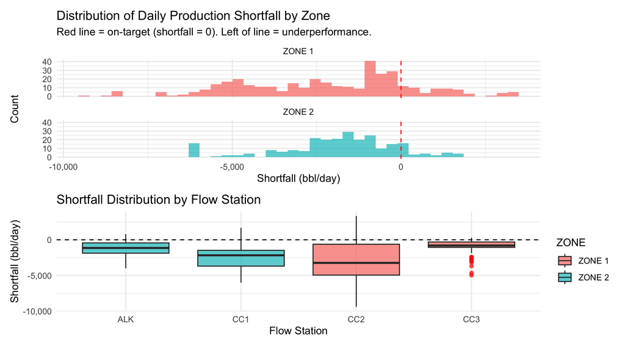

```r
# Distribution of shortfall by zone
p1 <- ggplot(prod_r, aes(x = shortfall, fill = ZONE)) +
  geom_histogram(bins = 40, alpha = 0.7, position = "identity") +
  geom_vline(xintercept = 0, linetype = "dashed", colour = "red") +
  facet_wrap(~ZONE, ncol = 1) +
  scale_x_continuous(labels = comma) +
  labs(title = "Distribution of Daily Production Shortfall by Zone",
       subtitle = "Red line = on-target (shortfall = 0). Left of line = underperformance.",
       x = "Shortfall (bbl/day)", y = "Count") +
  theme_minimal(base_size = 11) +
  theme(legend.position = "none")

# Box plot: shortfall by flow station
p2 <- ggplot(prod_r, aes(x = FLOW_STATIONS, y = shortfall, fill = ZONE)) +
  geom_boxplot(alpha = 0.7, outlier.colour = "red", outlier.size = 1.5) +
  geom_hline(yintercept = 0, linetype = "dashed") +
  scale_y_continuous(labels = comma) +
  labs(title = "Shortfall Distribution by Flow Station",
       x = "Flow Station", y = "Shortfall (bbl/day)") +
  theme_minimal(base_size = 11)

p1 / p2
```

```r
# Summary statistics by zone and station
prod_r |>
  group_by(ZONE, FLOW_STATIONS) |>
  summarise(
    n             = n(),
    mean_budget   = mean(BUDGET,    na.rm = TRUE),
    mean_actual   = mean(ACTUAL,    na.rm = TRUE),
    mean_shortfall = mean(shortfall, na.rm = TRUE),
    pct_days_under = mean(shortfall < 0) * 100,
    .groups = "drop"
  ) |>
  mutate(across(where(is.numeric), ~ round(., 1))) |>
  kable(caption = "EDA Summary: mean daily production and shortfall by zone and station",
        col.names = c("Zone","Station","n","Avg Budget","Avg Actual","Avg Shortfall","% Days Under Budget")) |>
  kable_styling(bootstrap_options = "striped", full_width = FALSE)
```

EDA Summary: mean daily production and shortfall by zone and station

| Zone | Station | n | Avg Budget | Avg Actual | Avg Shortfall | % Days Under Budget |
| --- | --- | --- | --- | --- | --- | --- |
| ZONE 1 | CC2 | 250 | 11838 | 9000.4 | -2837.6 | 80.0 |
| ZONE 1 | CC3 | 125 | 5324 | 4404.9 | -919.1 | 92.8 |
| ZONE 2 | ALK | 125 | 4156 | 2954.7 | -1201.3 | 91.2 |
| ZONE 2 | CC1 | 125 | 10760 | 8302.2 | -2457.8 | 88.0 |

**Python**

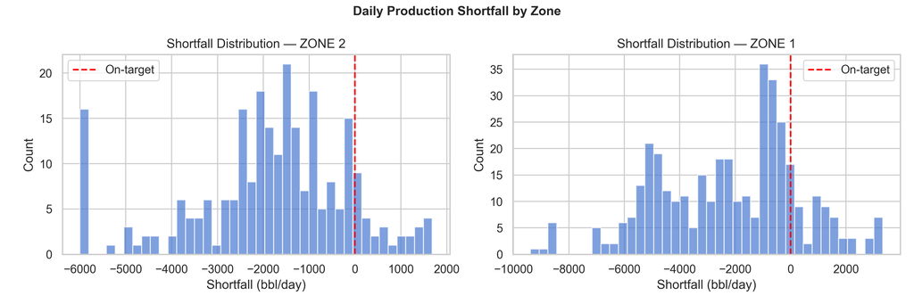

```python
zones = prod_py["ZONE"].dropna().unique()
fig, axes = plt.subplots(1, len(zones), figsize=(6 * len(zones), 4), squeeze=False)

for ax, zone in zip(axes[0], zones):
    subset = prod_py[prod_py["ZONE"] == zone]["shortfall"]
    ax.hist(subset, bins=40, alpha=0.7, edgecolor="white")
    ax.axvline(0, color="red", linestyle="--", label="On-target")
    ax.set_title(f"Shortfall Distribution — {zone}")
    ax.set_xlabel("Shortfall (bbl/day)")
    ax.set_ylabel("Count")
    ax.legend()

plt.suptitle("Daily Production Shortfall by Zone", fontsize=12, fontweight="bold")
plt.tight_layout()
plt.show()
```

```python
summary = prod_py.groupby(["ZONE", "FLOW_STATIONS"]).agg(
    n=("shortfall", "count"),
    mean_budget=("BUDGET", "mean"),
    mean_actual=("ACTUAL", "mean"),
    mean_shortfall=("shortfall", "mean"),
    pct_days_under=("shortfall", lambda x: (x < 0).mean() * 100)
).round(1).reset_index()
display(summary)
```

```
     ZONE FLOW_STATIONS    n  ...  mean_actual  mean_shortfall  pct_days_under
0  ZONE 1           CC2  250  ...       9000.4         -2837.6            80.0
1  ZONE 1           CC3  125  ...       4404.9          -919.1            92.8
2  ZONE 2           ALK  125  ...       2954.7         -1201.3            91.2
3  ZONE 2           CC1  125  ...       8302.2         -2457.8            88.0

[4 rows x 7 columns]
```

**Interpretation:** The shortfall distribution is left-skewed (negative side), meaning underperformance days are more frequent and deeper than overperformance days. Across the full sample, 86.4% of station-days fall below budget, confirming systemic production pressure rather than isolated volatility. At station level, CC2 has the largest mean deficit (-2,837.63 bbl/day), while CC3 has the highest share of under-budget days (92.8%), indicating highly persistent reliability constraints. Zone-level averages also show sustained deficits (Zone 1: -2,198.12 bbl/day; Zone 2: -1,829.56 bbl/day). Operationally, this pattern indicates that current throughput instability is chronic and concentrated in specific assets, so corrective action should prioritize persistent bottlenecks (CC2 and CC3) instead of one-off incident response.

## 6. Technique 2 — Data Visualization

**Business justification:** Time-series and comparative charts communicate throughput trends and zone performance to management in the format used in board briefings. The merged dataset enables visualizing how evacuation capacity tracks alongside production attainment.

**R**

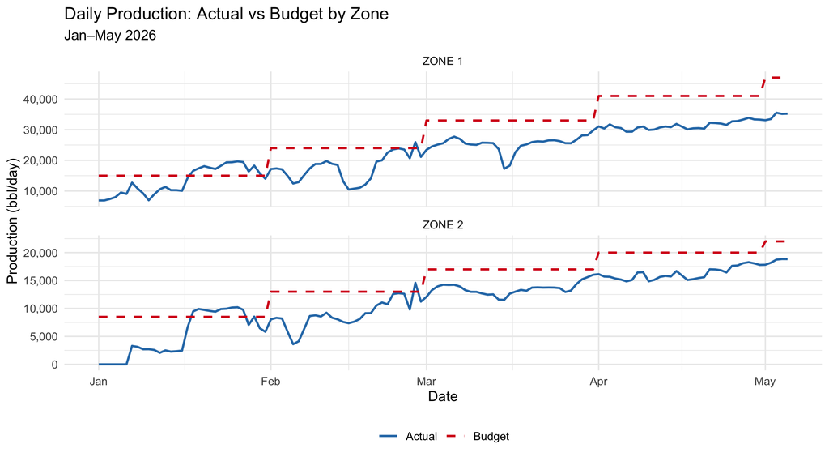

```r
# Time series: zone-level ACTUAL vs BUDGET
ggplot(df_r, aes(x = DATE)) +
  geom_line(aes(y = ACTUAL_zone, colour = "Actual"),  linewidth = 0.8) +
  geom_line(aes(y = BUDGET_zone, colour = "Budget"), linetype = "dashed", linewidth = 0.8) +
  facet_wrap(~ZONE, ncol = 1, scales = "free_y") +
  scale_y_continuous(labels = comma) +
  scale_colour_manual(values = c("Actual" = "#2c7bb6", "Budget" = "#d7191c")) +
  labs(title    = "Daily Production: Actual vs Budget by Zone",
       subtitle = "Jan–May 2026",
       x = "Date", y = "Production (bbl/day)", colour = NULL) +
  theme_minimal(base_size = 11) +
  theme(legend.position = "bottom")
```

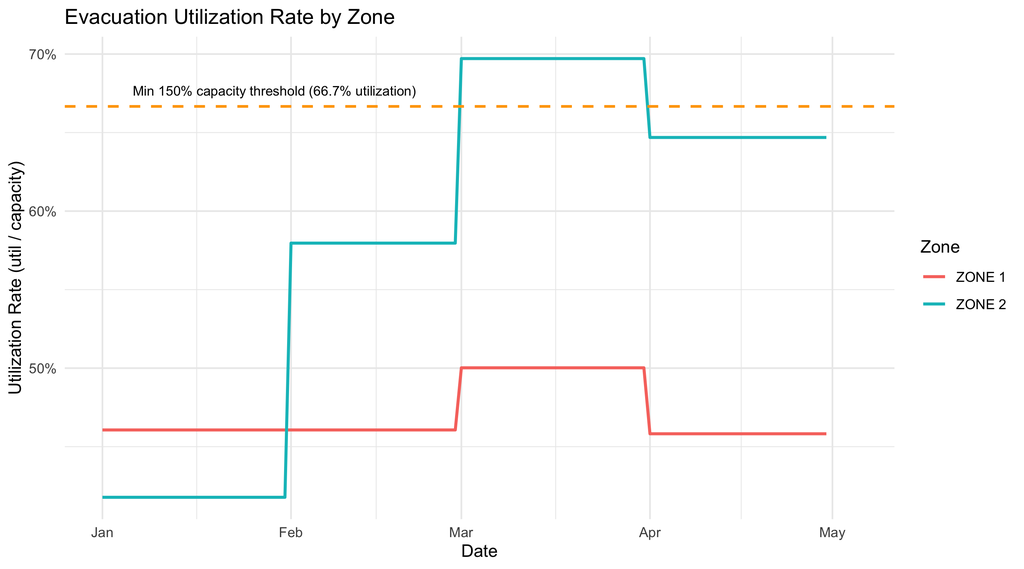

```r
# Evacuation utilization rate over time
ggplot(evac_r, aes(x = DATE, y = utilization_rate, colour = ZONE)) +
  geom_line(linewidth = 0.9) +
  geom_hline(yintercept = 1/1.5, linetype = "dashed", colour = "orange",
             linewidth = 0.8) +
  annotate("text", x = min(evac_r$DATE) + 5, y = 1/1.5 + 0.01,
           label = "Min 150% capacity threshold (66.7% utilization)", hjust = 0, size = 3) +
  scale_y_continuous(labels = percent_format()) +
  labs(title   = "Evacuation Utilization Rate by Zone",
       x = "Date", y = "Utilization Rate (util / capacity)", colour = "Zone") +
  theme_minimal(base_size = 11)
```

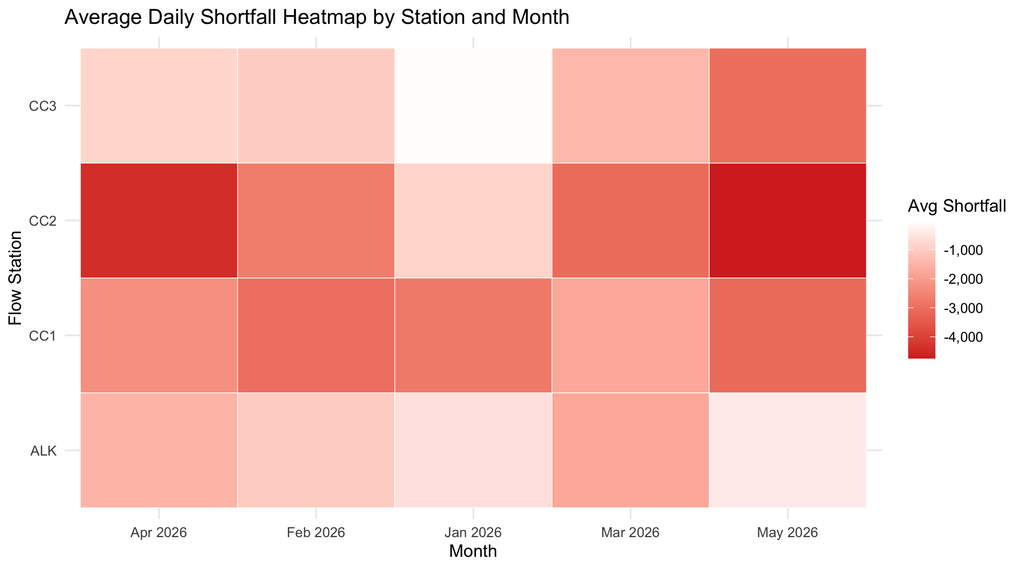

```r
# Heatmap: average shortfall by station and month
prod_r |>
  mutate(month_label = format(DATE, "%b %Y")) |>
  group_by(FLOW_STATIONS, month_label) |>
  summarise(avg_shortfall = mean(shortfall, na.rm = TRUE), .groups = "drop") |>
  ggplot(aes(x = month_label, y = FLOW_STATIONS, fill = avg_shortfall)) +
  geom_tile(colour = "white") +
  scale_fill_gradient2(low = "#d73027", mid = "white", high = "#1a9850",
                       midpoint = 0, labels = comma,
                       name = "Avg Shortfall") +
  labs(title = "Average Daily Shortfall Heatmap by Station and Month",
       x = "Month", y = "Flow Station") +
  theme_minimal(base_size = 11)
```

**Python**

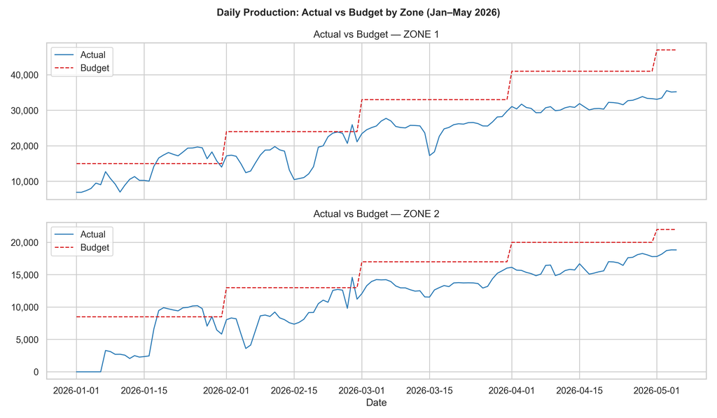

```python
fig, axes = plt.subplots(2, 1, figsize=(12, 7), sharex=True)

for ax, zone in zip(axes, df_py["ZONE"].unique()):
    z = df_py[df_py["ZONE"] == zone].sort_values("DATE")
    ax.plot(z["DATE"], z["ACTUAL_zone"], label="Actual", color="#2c7bb6", linewidth=1.2)
    ax.plot(z["DATE"], z["BUDGET_zone"], label="Budget", color="#d7191c",
            linestyle="--", linewidth=1.2)
    ax.set_title(f"Actual vs Budget — {zone}")
    ax.yaxis.set_major_formatter(mticker.FuncFormatter(lambda x, _: f"{x:,.0f}"))
    ax.legend()

plt.xlabel("Date")
fig.suptitle("Daily Production: Actual vs Budget by Zone (Jan–May 2026)",
             fontsize=12, fontweight="bold")
plt.tight_layout()
plt.show()
```

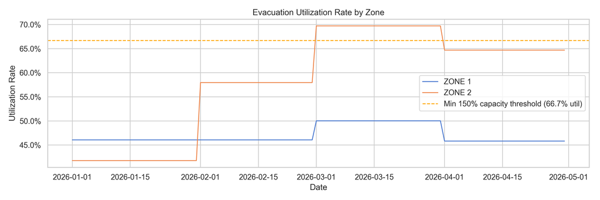

```python
fig, ax = plt.subplots(figsize=(12, 4))
for zone, grp in evac_py.groupby("ZONE"):
    grp = grp.sort_values("DATE")
    ax.plot(grp["DATE"], grp["utilization_rate"], label=zone, linewidth=1.2)

ax.axhline(1/1.5, color="orange", linestyle="--", linewidth=1.2,
           label="Min 150% capacity threshold (66.7% util)")
ax.yaxis.set_major_formatter(mticker.PercentFormatter(xmax=1))
ax.set_title("Evacuation Utilization Rate by Zone")
ax.set_xlabel("Date")
ax.set_ylabel("Utilization Rate")
ax.legend()
plt.tight_layout()
plt.show()
```

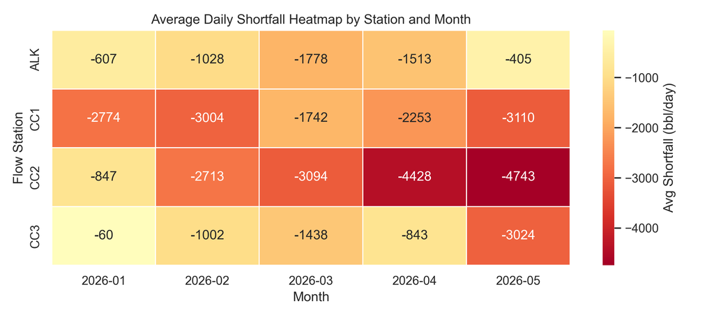

```python
heat = prod_py.copy()
heat["month_label"] = heat["DATE"].dt.to_period("M").astype(str)
pivot = heat.groupby(["FLOW_STATIONS", "month_label"])["shortfall"].mean().unstack()

fig, ax = plt.subplots(figsize=(9, 4))
sns.heatmap(pivot, cmap="RdYlGn", center=0, annot=True, fmt=".0f",
            linewidths=0.5, ax=ax, cbar_kws={"label": "Avg Shortfall (bbl/day)"})
ax.set_title("Average Daily Shortfall Heatmap by Station and Month")
ax.set_xlabel("Month")
ax.set_ylabel("Flow Station")
plt.tight_layout()
plt.show()
```

## 7. Technique 3 — Hypothesis Testing

**Business justification:** Formally tests whether Zone 1 and Zone 2 perform statistically differently against their respective budget targets — converting an operational observation into a statistically defensible basis for resource allocation decisions.

**R**

```r
# ── Test 1: One-way ANOVA — shortfall across zones ───────────────────────────
aov_zone <- aov(shortfall ~ ZONE, data = prod_r)
cat("=== ANOVA: Shortfall by Zone ===\n")
```

```
=== ANOVA: Shortfall by Zone ===
```

```r
aov_summary <- summary(aov_zone)
print(aov_summary[[1]])
```

```
             Df     Sum Sq  Mean Sq F value  Pr(>F)
ZONE          1   20375829 20375829  4.0829 0.04375 *
Residuals   623 3109107124  4990541
---
Signif. codes:  0 '***' 0.001 '**' 0.01 '*' 0.05 '.' 0.1 ' ' 1
```

```r
# Effect size (eta-squared) - calculate directly from ANOVA table
aov_table <- aov_summary[[1]]
ss_between <- aov_table["ZONE", "Sum Sq"]
ss_total <- sum(aov_table[, "Sum Sq"])
eta_sq <- ss_between / ss_total
cat(sprintf("\nEta-squared (effect size): %.4f\n", eta_sq))
```

```
Eta-squared (effect size): 0.0065
```

```r
cat("Interpretation: ", ifelse(eta_sq < 0.01, "negligible",
    ifelse(eta_sq < 0.06, "small",
    ifelse(eta_sq < 0.14, "medium", "large"))), " effect\n\n")
```

```
Interpretation:  negligible  effect
```

```r
# ── Test 2: ANOVA — shortfall across all four flow stations ─────────────────
aov_station <- aov(shortfall ~ FLOW_STATIONS, data = prod_r)
cat("=== ANOVA: Shortfall by Flow Station ===\n")
```

```
=== ANOVA: Shortfall by Flow Station ===
```

```r
summary(aov_station)
```

```
               Df    Sum Sq   Mean Sq F value Pr(>F)
FLOW_STATIONS   3 4.258e+08 141927843    32.6 <2e-16 ***
Residuals     621 2.704e+09   4353783
---
Signif. codes:  0 '***' 0.001 '**' 0.01 '*' 0.05 '.' 0.1 ' ' 1
```

```r
# Tukey HSD post-hoc if significant
tukey <- TukeyHSD(aov_station)
cat("\n=== Tukey HSD post-hoc pairwise comparisons (Flow Stations) ===\n")
```

```
=== Tukey HSD post-hoc pairwise comparisons (Flow Stations) ===
```

```r
print(tukey)
```

```
  Tukey multiple comparisons of means
    95% family-wise confidence level

Fit: aov(formula = shortfall ~ FLOW_STATIONS, data = prod_r)

$FLOW_STATIONS
              diff        lwr        upr     p adj
CC1-ALK -1256.5036 -1936.3947  -576.6125 0.0000143
CC2-ALK -1636.3280 -2225.1310 -1047.5250 0.0000000
CC3-ALK   282.2109  -397.6802   962.1020 0.7084211
CC2-CC1  -379.8244  -968.6274   208.9786 0.3449869
CC3-CC1  1538.7145   858.8234  2218.6056 0.0000001
CC3-CC2  1918.5389  1329.7359  2507.3419 0.0000000
```

```r
# Normality check
zones_r <- sort(unique(prod_r$ZONE))
shapiro_z1 <- shapiro.test(prod_r$shortfall[prod_r$ZONE == zones_r[1]])
shapiro_z2 <- shapiro.test(prod_r$shortfall[prod_r$ZONE == zones_r[2]])
cat("Shapiro-Wilk normality test:\n")
```

```
Shapiro-Wilk normality test:
```

```r
cat(sprintf("  %s: W=%.4f, p=%.4f\n", zones_r[1], shapiro_z1$statistic, shapiro_z1$p.value))
```

```
  ZONE 1: W=0.9800, p=0.0000
```

```r
cat(sprintf("  %s: W=%.4f, p=%.4f\n", zones_r[2], shapiro_z2$statistic, shapiro_z2$p.value))
```

```
  ZONE 2: W=0.9476, p=0.0000
```

```r
# If normality violated, run non-parametric Kruskal-Wallis
kw <- kruskal.test(shortfall ~ ZONE, data = prod_r)
cat(sprintf("\nKruskal-Wallis (non-parametric): chi-sq=%.4f, df=%d, p=%.4f\n",
            kw$statistic, kw$parameter, kw$p.value))
```

```
Kruskal-Wallis (non-parametric): chi-sq=1.6784, df=1, p=0.1951
```

**Python**

```python
from scipy.stats import f_oneway, kruskal, shapiro, tukey_hsd

zones = prod_py["ZONE"].unique()
groups = [prod_py[prod_py["ZONE"] == z]["shortfall"].dropna().values for z in zones]

# ANOVA
f_stat, p_anova = f_oneway(*groups)
print(f"=== One-way ANOVA: Shortfall by Zone ===")
```

```
=== One-way ANOVA: Shortfall by Zone ===
```

```python
print(f"F = {f_stat:.4f}, p = {p_anova:.4f}")
```

```
F = 4.0829, p = 0.0437
```

```python
print("Result:", "Significant difference" if p_anova < 0.05 else "No significant difference",
      "at 5% level\n")
```

```
Result: Significant difference at 5% level
```

```python
# Kruskal-Wallis (non-parametric robustness check)
h_stat, p_kw = kruskal(*groups)
print(f"=== Kruskal-Wallis (non-parametric): ===")
```

```
=== Kruskal-Wallis (non-parametric): ===
```

```python
print(f"H = {h_stat:.4f}, p = {p_kw:.4f}\n")
```

```
H = 1.6784, p = 0.1951
```

```python
# Normality check
print("=== Shapiro-Wilk Normality Test ===")
```

```
=== Shapiro-Wilk Normality Test ===
```

```python
for z, g in zip(zones, groups):
    stat, p = shapiro(g[:5000])  # Shapiro limited to 5000 samples
    print(f"  {z}: W={stat:.4f}, p={p:.4f}")
```

```
  ZONE 2: W=0.9476, p=0.0000
  ZONE 1: W=0.9800, p=0.0000
```

```python
stations = prod_py["FLOW_STATIONS"].unique()
station_groups = [prod_py[prod_py["FLOW_STATIONS"] == s]["shortfall"].dropna().values
                  for s in stations]

f_stat2, p_aov2 = f_oneway(*station_groups)
print(f"\n=== ANOVA: Shortfall by Flow Station ===")
```

```
=== ANOVA: Shortfall by Flow Station ===
```

```python
print(f"F = {f_stat2:.4f}, p = {p_aov2:.4f}")
```

```
F = 32.5987, p = 0.0000
```

```python
# Tukey HSD post-hoc
from statsmodels.stats.multicomp import pairwise_tukeyhsd
tukey_result = pairwise_tukeyhsd(
    endog=prod_py["shortfall"].dropna(),
    groups=prod_py.loc[prod_py["shortfall"].notna(), "FLOW_STATIONS"]
)
print(tukey_result.summary())
```

```
    Multiple Comparison of Means - Tukey HSD, FWER=0.05
===========================================================
group1 group2  meandiff  p-adj    lower      upper   reject
-----------------------------------------------------------
   ALK    CC1 -1256.5036    0.0 -1936.3947 -576.6125   True
   ALK    CC2  -1636.328    0.0  -2225.131 -1047.525   True
   ALK    CC3   282.2109 0.7084  -397.6802   962.102  False
   CC1    CC2  -379.8244  0.345  -968.6274  208.9786  False
   CC1    CC3  1538.7145    0.0   858.8234 2218.6056   True
   CC2    CC3  1918.5389    0.0  1329.7359 2507.3419   True
-----------------------------------------------------------
```

**Interpretation:** H0: Mean daily shortfall is equal across zones (and across stations for station-level ANOVA). H1: At least one group has a different mean shortfall.

## 8. Technique 4 — Correlation Analysis

**Business justification:** Maps the relationships between budget targets, actual production, evacuation capacity, and utilization before building the regression model. Identifies which evacuation variables have genuine independent predictive value.

**R**

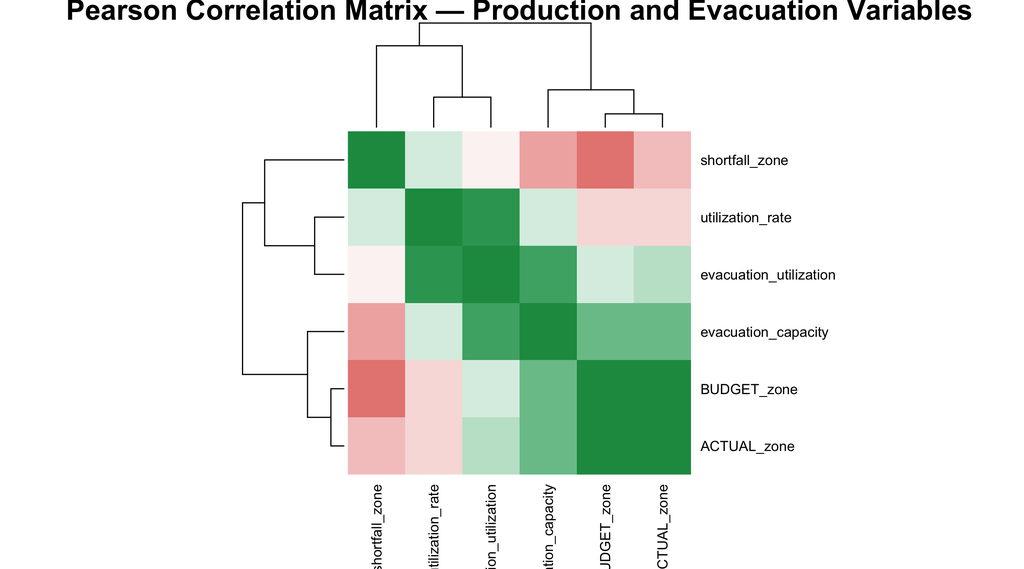

```r
# Correlation matrix on merged zone dataset
corr_vars <- df_r |>
  select(BUDGET_zone, ACTUAL_zone, shortfall_zone,
         evacuation_capacity, evacuation_utilization, utilization_rate) |>
  drop_na()

cor_matrix <- cor(corr_vars, method = "pearson")

# Use base R heatmap instead of ggcorrplot (which requires stringi)
par(mar = c(5, 4, 4, 2))
heatmap(cor_matrix,
  main = "Pearson Correlation Matrix — Production and Evacuation Variables",
  col = colorRampPalette(c("#d73027", "white", "#1a9850"))(20),
  symm = TRUE,
  breaks = seq(-1, 1, length.out = 21),
  cexRow = 0.9,
  cexCol = 0.9)
```

```r
# Top correlations with shortfall
cor_tbl <- as.data.frame(cor_matrix) |>
  rownames_to_column("Variable") |>
  select(Variable, shortfall_zone) |>
  filter(Variable != "shortfall_zone") |>
  arrange(desc(abs(shortfall_zone))) |>
  rename(Correlation_with_Shortfall = shortfall_zone)

kable(cor_tbl, digits = 4,
      caption = "Correlation of each variable with daily zone-level shortfall") |>
  kable_styling(bootstrap_options = "striped", full_width = FALSE)
```

Correlation of each variable with daily zone-level shortfall

| Variable | Correlation_with_Shortfall |
| --- | --- |
| BUDGET_zone | -0.5964 |
| evacuation_capacity | -0.3609 |
| ACTUAL_zone | -0.2656 |
| utilization_rate | 0.1825 |
| evacuation_utilization | -0.0615 |

**Python**

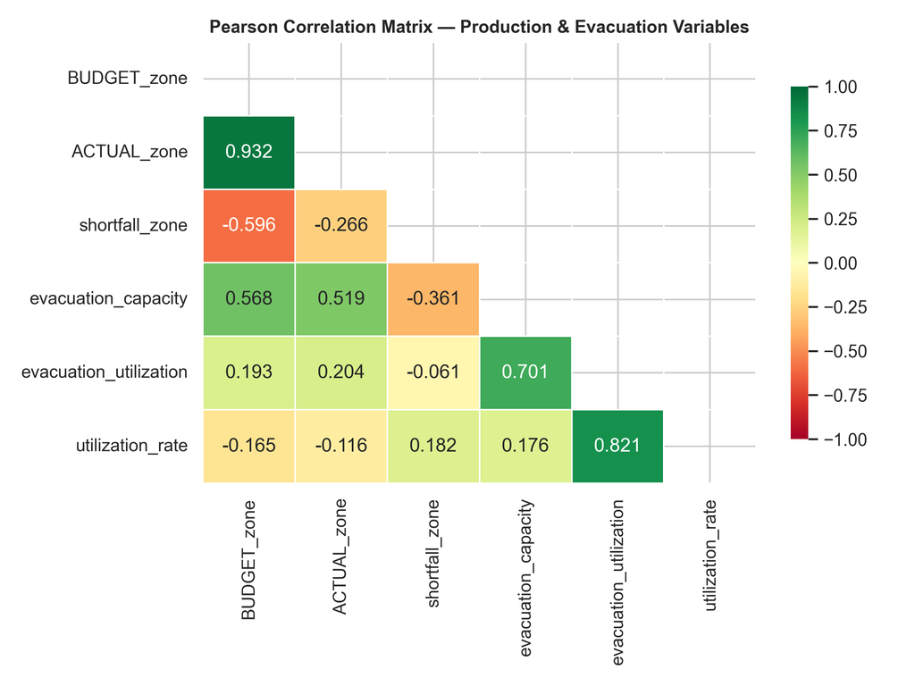

```python
corr_cols = ["BUDGET_zone", "ACTUAL_zone", "shortfall_zone",
             "evacuation_capacity", "evacuation_utilization", "utilization_rate"]
corr_data = df_py[corr_cols].dropna()
cor_mat = corr_data.corr(method="pearson")

fig, ax = plt.subplots(figsize=(8, 6))
mask = np.triu(np.ones_like(cor_mat, dtype=bool))
sns.heatmap(cor_mat, mask=mask, annot=True, fmt=".3f", cmap="RdYlGn",
            center=0, vmin=-1, vmax=1,
            linewidths=0.5, ax=ax,
            cbar_kws={"shrink": 0.8})
ax.set_title("Pearson Correlation Matrix — Production & Evacuation Variables",
             fontsize=11, fontweight="bold")
plt.tight_layout()
plt.show()
```

```python
shortfall_corr = cor_mat["shortfall_zone"].drop("shortfall_zone").sort_values(
    key=abs, ascending=False
)
print("Correlation with shortfall_zone:\n")
```

```
Correlation with shortfall_zone:
```

```python
print(shortfall_corr.round(4).to_string())
```

```
BUDGET_zone              -0.5964
evacuation_capacity      -0.3609
ACTUAL_zone              -0.2656
utilization_rate          0.1825
evacuation_utilization   -0.0615
```

## 9. Technique 5 — Multiple Regression

**Business justification:** Quantifies the independent contribution of zone, evacuation capacity, and utilization to daily production shortfall. The resulting coefficients support concrete fleet-sizing and capacity-allocation recommendations.

**R**

```r
# Encode ZONE as factor
df_r$ZONE_f <- factor(df_r$ZONE)

# Model: shortfall ~ ZONE + evacuation_capacity + utilization_rate
model <- lm(shortfall_zone ~ ZONE_f + evacuation_capacity + utilization_rate,
            data = df_r)

cat("=== Regression: Daily Zone Shortfall ===\n")
```

```
=== Regression: Daily Zone Shortfall ===
```

```r
summary(model)
```

```
Call:
lm(formula = shortfall_zone ~ ZONE_f + evacuation_capacity +
    utilization_rate, data = df_r)

Residuals:
    Min      1Q  Median      3Q     Max
-9226.8 -1480.3  -206.3  1481.0  9262.5

Coefficients:
                      Estimate Std. Error t value Pr(>|t|)
(Intercept)         2856.66619 1737.79253   1.644    0.102
ZONE_fZONE 2        2987.76348  524.33100   5.698 3.59e-08 ***
evacuation_capacity   -0.56020    0.07534  -7.436 1.91e-12 ***
utilization_rate     861.67142 2759.28188   0.312    0.755
---
Signif. codes:  0 '***' 0.001 '**' 0.01 '*' 0.05 '.' 0.1 ' ' 1

Residual standard error: 3251 on 236 degrees of freedom
  (10 observations deleted due to missingness)
Multiple R-squared:  0.2904,    Adjusted R-squared:  0.2813
F-statistic: 32.19 on 3 and 236 DF,  p-value: < 2.2e-16
```

```r
# Coefficient table - extract directly from model to avoid stringi dependency
coef_data <- data.frame(
  term = names(coef(model)),
  estimate = coef(model),
  std.error = sqrt(diag(vcov(model))),
  row.names = NULL
)
coef_data$t.value <- coef_data$estimate / coef_data$std.error
coef_data$p.value <- 2 * pt(abs(coef_data$t.value), df = model$df.residual, lower.tail = FALSE)
coef_data$conf.low <- coef_data$estimate - 1.96 * coef_data$std.error
coef_data$conf.high <- coef_data$estimate + 1.96 * coef_data$std.error
coef_data[, -1] <- round(coef_data[, -1], 4)
kable(coef_data, caption = "Regression coefficients with 95% confidence intervals") |>
  kable_styling(bootstrap_options = "striped", full_width = FALSE)
```

Regression coefficients with 95% confidence intervals

| term | estimate | std.error | t.value | p.value | conf.low | conf.high |
| --- | --- | --- | --- | --- | --- | --- |
| (Intercept) | 2856.6662 | 1737.7925 | 1.6438 | 0.1015 | -549.4072 | 6262.7396 |
| ZONE_fZONE 2 | 2987.7635 | 524.3310 | 5.6982 | 0.0000 | 1960.0747 | 4015.4522 |
| evacuation_capacity | -0.5602 | 0.0753 | -7.4359 | 0.0000 | -0.7079 | -0.4125 |
| utilization_rate | 861.6714 | 2759.2819 | 0.3123 | 0.7551 | -4546.5211 | 6269.8639 |

```r
# Model fit - extract directly from model summary
model_summary <- summary(model)
fit_data <- data.frame(
  r.squared = round(model_summary$r.squared, 4),
  adj.r.squared = round(model_summary$adj.r.squared, 4),
  fstatistic = round(model_summary$fstatistic[1], 4),
  p.value = round(pf(model_summary$fstatistic[1], model_summary$fstatistic[2],
                     model_summary$fstatistic[3], lower.tail = FALSE), 4),
  AIC = round(AIC(model), 4),
  BIC = round(BIC(model), 4)
)
kable(fit_data, caption = "Model fit statistics") |>
  kable_styling(full_width = FALSE)
```

Model fit statistics

|  | r.squared | adj.r.squared | fstatistic | p.value | AIC | BIC |
| --- | --- | --- | --- | --- | --- | --- |
| value | 0.2904 | 0.2813 | 32.1862 | 0 | 4568.61 | 4586.014 |

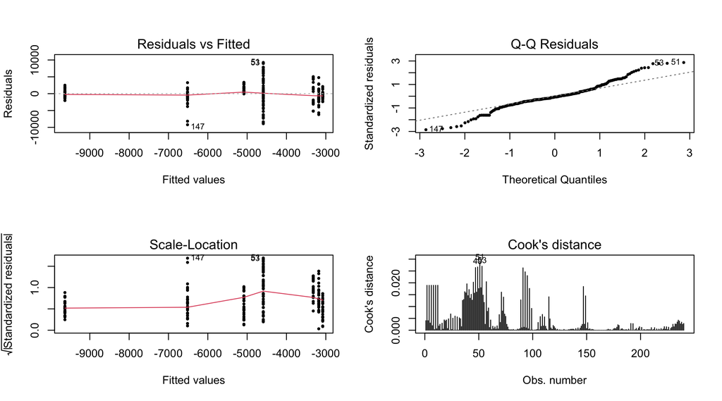

```r
# Diagnostic plots
par(mfrow = c(2, 2))
plot(model, which = 1:4, pch = 16, cex = 0.6)
```

```r
par(mfrow = c(1, 1))
```

**Python**

```python
import statsmodels.formula.api as smf

df_reg = df_py.dropna(subset=["shortfall_zone", "evacuation_capacity",
                               "utilization_rate", "ZONE"])

# Encode ZONE
df_reg = df_reg.copy()
df_reg["ZONE_f"] = pd.Categorical(df_reg["ZONE"])

model_py = smf.ols(
    "shortfall_zone ~ C(ZONE_f) + evacuation_capacity + utilization_rate",
    data=df_reg
).fit()

print(model_py.summary())
```

```
                            OLS Regression Results
==============================================================================
Dep. Variable:         shortfall_zone   R-squared:                       0.290
Model:                            OLS   Adj. R-squared:                  0.281
Method:                 Least Squares   F-statistic:                     32.19
Date:                Tue, 19 May 2026   Prob (F-statistic):           1.77e-17
Time:                        09:54:51   Log-Likelihood:                -2279.3
No. Observations:                 240   AIC:                             4567.
Df Residuals:                     236   BIC:                             4581.
Df Model:                           3
Covariance Type:            nonrobust
=======================================================================================
                          coef    std err          t      P>|t|      [0.025      0.975]
---------------------------------------------------------------------------------------
Intercept            2856.6662   1737.793      1.644      0.102    -566.901    6280.234
C(ZONE_f)[T.ZONE 2]  2987.7635    524.331      5.698      0.000    1954.796    4020.731
evacuation_capacity    -0.5602      0.075     -7.436      0.000      -0.709      -0.412
utilization_rate      861.6714   2759.282      0.312      0.755   -4574.298    6297.641
==============================================================================
Omnibus:                        8.336   Durbin-Watson:                   0.636
Prob(Omnibus):                  0.015   Jarque-Bera (JB):               13.090
Skew:                           0.172   Prob(JB):                      0.00144
Kurtosis:                       4.091   Cond. No.                     2.58e+05
==============================================================================

Notes:
[1] Standard Errors assume that the covariance matrix of the errors is correctly specified.
[2] The condition number is large, 2.58e+05. This might indicate that there are
strong multicollinearity or other numerical problems.
```

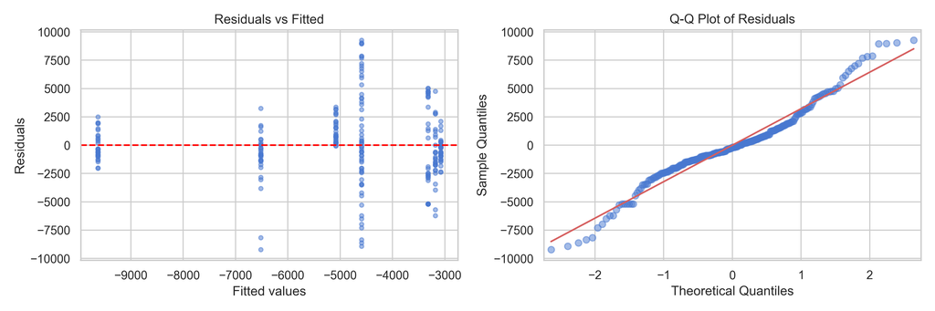

```python
# Residual plot
fig, axes = plt.subplots(1, 2, figsize=(12, 4))

# Residuals vs Fitted
axes[0].scatter(model_py.fittedvalues, model_py.resid, alpha=0.5, s=15)
axes[0].axhline(0, color="red", linestyle="--")
axes[0].set_xlabel("Fitted values")
axes[0].set_ylabel("Residuals")
axes[0].set_title("Residuals vs Fitted")

# Q-Q plot
sm.qqplot(model_py.resid, line="s", ax=axes[1], alpha=0.5)
axes[1].set_title("Q-Q Plot of Residuals")

plt.tight_layout()
plt.show()
```

```python
print(f"\nR-squared: {model_py.rsquared:.4f}")
```

```
R-squared: 0.2904
```

```python
print(f"Adj. R-squared: {model_py.rsquared_adj:.4f}")
```

```
Adj. R-squared: 0.2813
```

```python
print(f"F-statistic p-value: {model_py.f_pvalue:.6f}")
```

```
F-statistic p-value: 0.000000
```

## References

- Wickham, H., & Grolemund, G. (2017). *R for Data Science*. O’Reilly Media.
- McKinney, W. (2022). *Python for Data Analysis* (3rd ed.). O’Reilly Media.
- Adi, B. (2026). *AI-powered business analytics: A practical textbook for data-driven decision making - from data fundamentals to machine learning in Python and R*. Lagos Business School / markanalytics.online. https://markanalytics.online
- R Core Team. (2024). *R: A language and environment for statistical computing*. R Foundation for Statistical Computing.
- Pedersen, T. L. (2024). *patchwork: The Composer of Plots* (R package).
- Kassambara, A. (2024). *ggcorrplot: Visualization of a Correlation Matrix using ggplot2* (R package).
- Xie, Y. (2024). *knitr: A General-Purpose Package for Dynamic Report Generation in R* (R package).

## Appendix: AI Usage Statement

GitHub Copilot (Microsoft) and ChatGPT (OpenAI) were used to accelerate structure design, code templating, and review of statistical workflow sequencing. All dataset-specific cleaning rules, test selection, threshold definitions, coefficient interpretation, and operational recommendations were independently validated by the author against the actual outputs generated from internal production and evacuation data. Final conclusions and business actions reflect the author’s professional judgement and accountability.